# UV-Vis peak prediction from topological features

## Summary

MLP regression of topological features responsible for UV-Vis activity against computational $\lambda_{max}$ values (sTDA) was studied. The best model gave an R$^2$ score of 0.74 against target values in the test data, suggesting a decent model for rapid wavelength estimation.

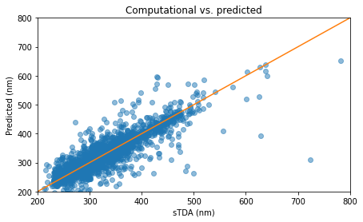

## Introduction

UV-VIS absorption peaks in molecules can be estimated with topological rules like the [Woodward-Fieser rules](https://en.wikipedia.org/wiki/Woodward%27s_rules) or its derivatives. Such methods are fast to calculate but fail with long conjugation paths or with complex patterns. More precise DFT computations can also be used but they are relatively slow to be used in large scale. The aim of this study was to generate topological path fingerprints of a molecule and train an MLP regressor for fast $\lambda_{max}$ estimation. The practical purpose of this was to screen molecules with UV-Vis activity in the range of ca. 400 - 700 nm with an accuracy of $\pm$50 nm.

## Fingerprint

The fingerprint generation process is described below with an example. First, all conjugated sub graphs are searched within the molecule with DFS. Then, the largest conjugated graph is selected (highest wavelength), after which non-conjugated substituent atoms are added to the sub graph. The conjugation fingerprint is a sparse vector of all N-atom path occurrences in the sub graph. Below is shown a 3-atom path example:

[figure not shown]

Each atom in the path is described by atom symbol, hybridization state, aromaticity and explicit valence, encoded in a hashable string. The fingerprint for the example molecule would therefore be:

```
       ATOM1         ATOM2           ATOM 3         COUNT
 "C SP2 True 3   C SP2 True 4   C  SP3 False 2"    : 1        (green in pic)
 "C SP2 True 4   C SP2 True 4   C  SP3 False 2"    : 1
 "C SP2 True 3   C SP2 True 3   C  SP2 True  4"    : 2
 "C SP2 True 3   C SP2 True 4   C  SP2 True  4"    : 2
 "C SP2 True 4   C SP2 True 4   Cl SP3 False 1"    : 1
 "C SP2 True 3   C SP2 True 3   C  SP2 True  3"    : 2        (red in pic)
 "C SP2 True 3   C SP2 True 4   Cl SP3 False 1"    : 1        (blue in pic)
```

Canonical output is ensured by reversing the atom path order to ascending alphabetic order when required. The function also allows an option for non-ordered paths for reduced dimensionality.

All molecules in the training set are treated, and all path string keys are added to a unique index list. Vectorization of each fingerprint is done by looking up the indices of the path string keys from the index list, and setting the element values according to the index and fingerprint count. Pseudo code below:

```
# Generate unique index list
index_list = []
for mol in molecules:
   for atom_path_key in mol.fingerprint.keys():
       if atom_path_key not in index_list:
           index_list.append(atom_path_key)

# Vectorization
input_data = zeroes[len(molecules)][len(index_list)]
for mol in molecules:
   for atom_path_key in mol.fingerprint.keys():
      input_data[mol.index, index_list.indexOf(atom_path_key)] = mol.fingerprint[atom_path_key]
```

The fingerprint is not generated for a molecule if the size of the maximum conjugated sub graph is less than 4 atoms.

Code for the fingerprint generation:

Show Code

```python
def get_fingerprint_from_smiles(smi, path_length = 4, path_is_ordered = True, verbose = False):

    mol = Chem.MolFromSmiles(smi)
    Chem.rdmolops.RemoveHs(mol)

    # DFS Search to find all conjugated bonds
    # Results in a list of sets of atom index pairs in conjugated_bonds
    # e.g. conjugated_bonds = [{0, 1}, {1, 2}, {2, 3}]
    conjugated_bonds = []
    visited_bonds = []
    bond_stack = [mol.GetBonds()[0]]

    while(len(bond_stack) > 0):
        this_bond = bond_stack.pop()
        begin_atom_idx = this_bond.GetBeginAtom().GetIdx()
        end_atom_idx = this_bond.GetEndAtom().GetIdx()

        visited_bonds.append({begin_atom_idx, end_atom_idx})

        if this_bond.GetIsConjugated():
            conjugated_bonds.append({begin_atom_idx, end_atom_idx})

        for bond in mol.GetAtomWithIdx(end_atom_idx).GetBonds():
            if {bond.GetBeginAtom().GetIdx(), bond.GetEndAtom().GetIdx()} not in visited_bonds:
                bond_stack.append(bond)

    # Return None if no conjugated paths were found
    if len(conjugated_bonds) == 0:
        return None

    if verbose:
        print("Conjugated bonds:")
        print(conjugated_bonds)


    ### Generate connected conjugation sets from a list of atom pairs
    ### e.g. [{0, 1}, {1, 2}, {2, 3}, {3, 4}, {4, 5}, {0, 5}, {6, 7}, {7, 8}]
    ###  --> [{0,1,2,3,4,5}, {6,7,8}]

    conjugated_sets = []
    for bond in conjugated_bonds:
        appended_to_set = False

        # Check if this bond can be added to existing conjugated set
        for conj_set in conjugated_sets:
            if len(bond.intersection(conj_set)) > 0:
                conj_set.update(bond)
                appended_to_set = True

        # Else create new conjugated set
        if appended_to_set == False:
            conjugated_sets.append(bond)

    if verbose:
        print("Conjugated sets:")
        print(conjugated_sets)



    ### Find the largest conjugation set; this will be used for the lambda prediction
    ### Return None if too short (< 4 atoms)

    set_sizes = [len(x) for x in conjugated_sets]
    max_conjugated_set = conjugated_sets[np.argmax(set_sizes)]

    if len(max_conjugated_set) < 4:
        if verbose:
            print("Too small max. conjugated set")
        return None
    if verbose:
        print("Max set:")
        print(max_conjugated_set)


    ### Find all substituent atoms connected directly to the conjugated sub graph

    substituent_atoms = set()
    for atom_idx in max_conjugated_set:
        for bond in mol.GetAtomWithIdx(atom_idx).GetBonds():
            substituent_atoms.add(bond.GetBeginAtom().GetIdx()) # Add both atoms so the
            substituent_atoms.add(bond.GetEndAtom().GetIdx())   # subst. atom will be added
    max_conjugated_set.update(substituent_atoms)


    ### Generate all atom paths of size path_length within the molecule
    ### retain only if all atoms in the route belong to max_conjugated_set

    atom_paths = []
    for atom_idx in max_conjugated_set:
        paths = Chem.rdmolops.FindAllPathsOfLengthN(mol, path_length, rootedAtAtom=atom_idx, useBonds = False)
        for p in paths:
            path_list = []
            for path_atom in p:
                path_list.append(path_atom)

            # Check if all atoms exist in max_conjugated_set
            if len(max_conjugated_set.intersection(set(path_list))) == len(path_list):
                atom_paths.append(path_list)

    if verbose:
        print("Atom paths: ")
        print(atom_paths)



    ### Generate atom path strings
    atom_paths_dict = {}
    duplicate_check_list = []
    for path in atom_paths:
        atom_string_list = []
        duplicate_check = []
        for atom_idx in path:
            atom = mol.GetAtomWithIdx(atom_idx)
            atom_string_list.append(str(atom.GetSymbol()) + " " + str(atom.GetHybridization()) + " " + str(atom.GetIsAromatic()) + " " + str(atom.GetExplicitValence()))
            duplicate_check.append(atom_idx)
        if duplicate_check in duplicate_check_list or list(reversed(duplicate_check)) in duplicate_check_list:
            continue
        duplicate_check_list.append(duplicate_check)

        if path_is_ordered == False:
            atom_string_list.sort()
        needs_reverse = False
        for i in range(0, len(atom_string_list)):
            if atom_string_list[i] > atom_string_list[-(i + 1)]:
                needs_reverse = True
            else:
                break
        if needs_reverse:
            if verbose:
                print("Before combining both directions " + str(atom_string_list))

            tmp_string = []
            for i in range(0, len(atom_string_list)):
                tmp_string.append(atom_string_list[-(i + 1)])
            atom_string_list = tmp_string
            if verbose:
                print("After combining both directions " + str(atom_string_list))


        path_string = " . ".join(atom_string_list)
        if path_string not in atom_paths_dict:
            atom_paths_dict[path_string] = 1
        else:
            atom_paths_dict[path_string] += 1

    if verbose:
        print("Conjugated atom paths: ")
        for ap in atom_paths_dict:
            print(str(ap) + ": " + str(atom_paths_dict[ap]))

    return atom_paths_dict
```

## Dataset

The data was downloaded from https://www.nature.com/articles/s41597-019-0306-0 that collected experimental and computational (TD-DFT, sTDA) $\lambda_{max}$ values for 8500 molecules extracted automatically from the literature, along with their SMILES strings. Clearly erroneous values were spotted from the experimental column (rows 2 & 5 below, for example), which is why computational values (sTDA) were chosen as the target. Also, because computational values are essentially "measured" in vacuum condition while the experimental values may be affected by solvent conditions etc., the sTDA values having less noise serve better the purpose of this study.

Show Code

```
                                                 SMI  sTDA (nm)  Exp. (nm)
1  Oc1cc(O)c2c(c1)O[C@@H]([C@@H](C2)OC(=O)c1cc(O)...      263.5      280.0
2                 Brc1[nH]c2c(n1)c(Br)c(c(c2Br)Br)Br      264.0      940.0
3                         Clc1ccc(c(c1)Cl)OCCn1cncc1      245.2      254.0
5  CC(=O)O[C@H]1[C@@H](O[C@@H]([C@H]1C(F)(F)F)COC...      242.5      931.0
6                      COC(=O)Cc1ccc(cc1)OC[C@H]1OC1      245.9      225.0

Dataset shape after range check and removing null values: (6130, 3)
```

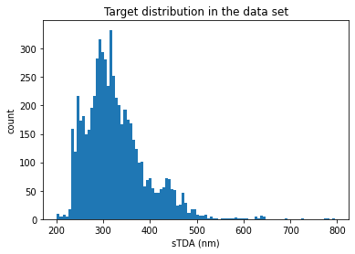

```python
### Read UV-Vis data; get SMILES, sTDA (nm) and experimental (nm) columns only
df = pd.read_csv("paper_allDB.csv", header = 0, usecols = [0, 1, 5])
df.columns = ["SMI", "sTDA (nm)", "Exp. (nm)"]

### Retain rows with Lambda in range [200, 800]
df = df[df['sTDA (nm)'].notnull()]
df = df[df["sTDA (nm)"] <= 800]
df = df[df["sTDA (nm)"] >= 200]

print(df.iloc[0:5, :])

print("\nDataset shape after range check and removing null values: " + str(df.shape))

plt.hist(df["sTDA (nm)"], bins = 100)
plt.xlabel('sTDA (nm)')
plt.ylabel('count')
plt.title('Target distribution in the data set')
plt.show()
```

The dataset was highly biased in target values. Naive oversampling was therefore experimented in the training data to see if any overfitting could be prevented.

## MLP

The neural network architecture was a 1-hidden layer MLP with hidden node count being 60% of input vector length. ReLU activation was used, and the input vectors were scaled to [0, 1] before feeding to the net. Adam optimizer with a learning rate of 0.001 was utilized, and MSE was used as the loss function. These are very simple parameters for the MLP regressor, and a quick test for example with additional hidden layers did not bring any benefit.

60% of the input data was assigned to the training set and 40% to the test set, leading to around 3700 molecules in training and 2400 in testing.

Show Code

```python
### Split to train and test sets
X_train, X_test, y_train, y_test, smi_train, smi_test = train_test_split(input_data, output_data, smiles_data, test_size=0.4, random_state=42)

### Discard features with entries in only one row
retained_features = np.sum(X_train > 0, axis = 0) > 1
X_train = X_train[:, retained_features]
X_test = X_test[:, retained_features]

print("X_train shape: " + str(X_train.shape))
print("X_test shape: " + str(X_test.shape))


### Naive oversampling: divide y range to n_bins
### and fill all bins to max by resampling from each bin

oversampling = False
if oversampling:
    n_bins = 20
    y_bin_labels = np.round((y_train - np.min(y_train)) / (np.max(y_train) - np.min(y_train)) * n_bins)
    y_bins_count = [np.sum(y_bin_labels == y) for y in range(0, n_bins)]
    for y_bin in range(0, n_bins):
       if y_bins_count[y_bin] == 0:	# Cannot sample from an empty bin
          continue
       # Number of entries to be sampled
       n_to_resample = max(y_bins_count) - y_bins_count[y_bin]

       # Bin population
       y_bin_idxs = np.where(y_bin_labels == y_bin)[0]
       # Sample from the bin population
       sampled_idxs = np.random.choice(y_bin_idxs, n_to_resample)

       # Append to training data
       y_train = np.concatenate((y_train, y_train[sampled_idxs]))
       X_train = np.vstack((X_train, X_train[sampled_idxs,:]))




### MLP Regression
reg = MLPRegressor(random_state=11, hidden_layer_sizes=(round(X_train.shape[1]*0.6)), max_iter=5000)
reg.fit(X_train, y_train.ravel())
print("Train score: " + str(reg.score(X_train, y_train)))
print("Test score:  " + str(reg.score(X_test, y_test)))




yhat_test = reg.predict(X_test)

test_results = []
for y in range(0, yhat_test.shape[0]):
    test_results.append([y_test[y], yhat_test[y], smi_test.iloc[y, 0]])

### Calculate outliers (+- 50 nm from target)
outliers = [x for x in test_results if np.abs(x[0] - x[1]) > 50]
outlierp = np.floor(len(outliers) / yhat_test.shape[0] * 100)
print("Outliers (+- 50 nm from target): " + str(outlierp) + " %")

### Get best entries
best = [x for x in test_results if np.abs(x[0] - x[1]) < 1]
```

## Results

| **Path length** | **Ordered path** | **Oversampling** | **Train score** | **Test score** | **> $\pm$50 nm** | **Features** |
| --- | --- | --- | --- | --- | --- | --- |
| 2 | False | False | 0.83 | 0.68 | 26% | 139 |
| 3 | True | False | 0.96 | 0.71 | 10% | 485 |
| 3 | False | False | 0.93 | 0.70 | 8% | 367 |
| 4 | True | False | 0.98 | 0.74 | 8% | 1432 |
| 4 | False | False | 0.95 | 0.70 | 9% | 848 |
| 4 | True | True | 0.99 | 0.71 | 9% | 1432 |

The molecular structures do not seem to explain the differences between outliers and good predictions as there seem to be no common patterns shared by the outliers (see structures below). Also, there are highly complex structures with good predictions, suggesting that the differences indeed arise from the electron density level. Possibly the fit could be improved by encoding more atomic properties in the fingerprint (distributed charges etc.) - however, that would also increase the number of features and result in a more complex model requiring more training data.

### Path length 4, ordered path, no oversampling

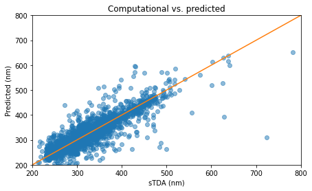

### 6 random outliers (predicted > target $\pm$ 50 nm)

```
real    pred
399.8   281.3
322.5   391.4
782.0   652.6
256.5   201.5
627.7   391.7
450.8   569.6
```

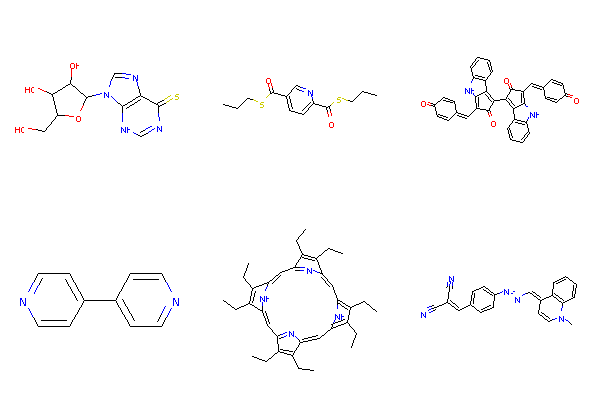

### 6 random good predictions (predicted < target $\pm$ 1 nm)

```
real    pred
267.1   266.3
273.7   273.6
346.5   347.0
388.8   388.8
323.6   322.8
368.4   367.4
```

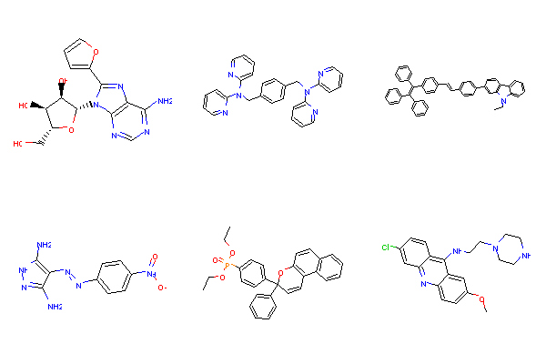